# Unit 3 Project

Ian Lee

2026-02-06

Below is a template to get you started on the Unit 3 Project. Make sure you edit the metadata above to include your name. For questions that include code, the template to produce `R` chunks is below. **Any code you write that produces an output must be fully visible in the HTML document you hand in!**

```r
library(tidyverse)
```

```r
library(dplyr)
library(ggplot2)
library(GGally)
str(iris)
```

```
## 'data.frame':    150 obs. of  5 variables:
##  $ Sepal.Length: num  5.1 4.9 4.7 4.6 5 5.4 4.6 5 4.4 4.9 ...
##  $ Sepal.Width : num  3.5 3 3.2 3.1 3.6 3.9 3.4 3.4 2.9 3.1 ...
##  $ Petal.Length: num  1.4 1.4 1.3 1.5 1.4 1.7 1.4 1.5 1.4 1.5 ...
##  $ Petal.Width : num  0.2 0.2 0.2 0.2 0.2 0.4 0.3 0.2 0.2 0.1 ...
##  $ Species     : Factor w/ 3 levels "setosa","versicolor",..: 1 1 1 1 1 1 1 1 1 1 ...
```

# Part I: Morphological Data

```r
iris %>%
  group_by(Species) %>%
  summarize(across(where(is.numeric), mean))
```

```
## # A tibble: 3 × 5
##   Species    Sepal.Length Sepal.Width Petal.Length Petal.Width
##   <fct>             <dbl>       <dbl>        <dbl>       <dbl>
## 1 setosa             5.01        3.43         1.46       0.246
## 2 versicolor         5.94        2.77         4.26       1.33
## 3 virginica          6.59        2.97         5.55       2.03
```

## Question 2

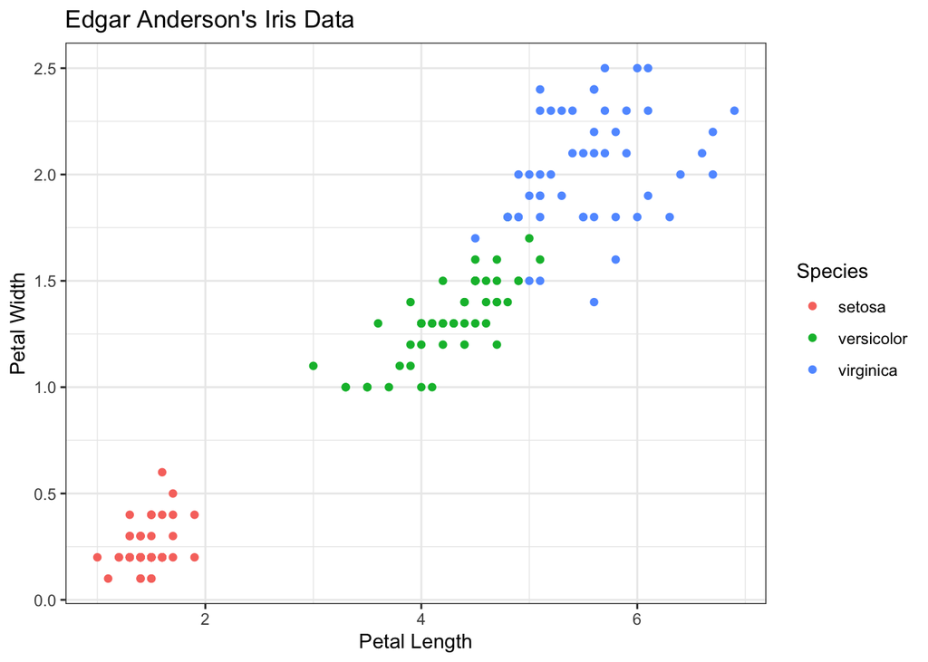

```r
ggplot(iris, aes(x = Petal.Length, y = Petal.Width, color = Species)) + geom_point() + labs(title = "Edgar Anderson's Iris Data", x = "Petal Length", y = "Petal Width") + theme_bw()
```

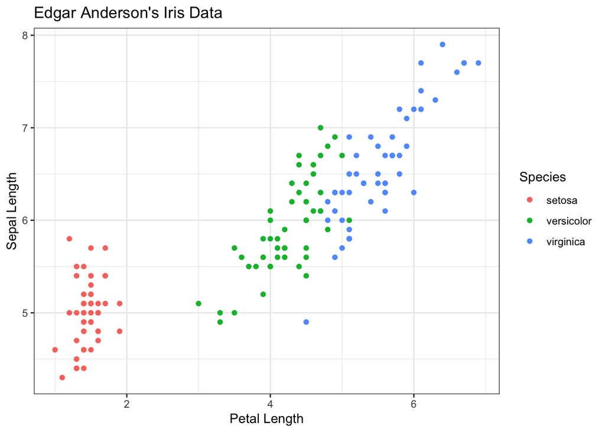

```r
ggplot(iris, aes(x = Petal.Length, y = Sepal.Length, color = Species)) + geom_point() + labs(title = "Edgar Anderson's Iris Data", x = "Petal Length", y = "Sepal Length") + theme_bw()
```

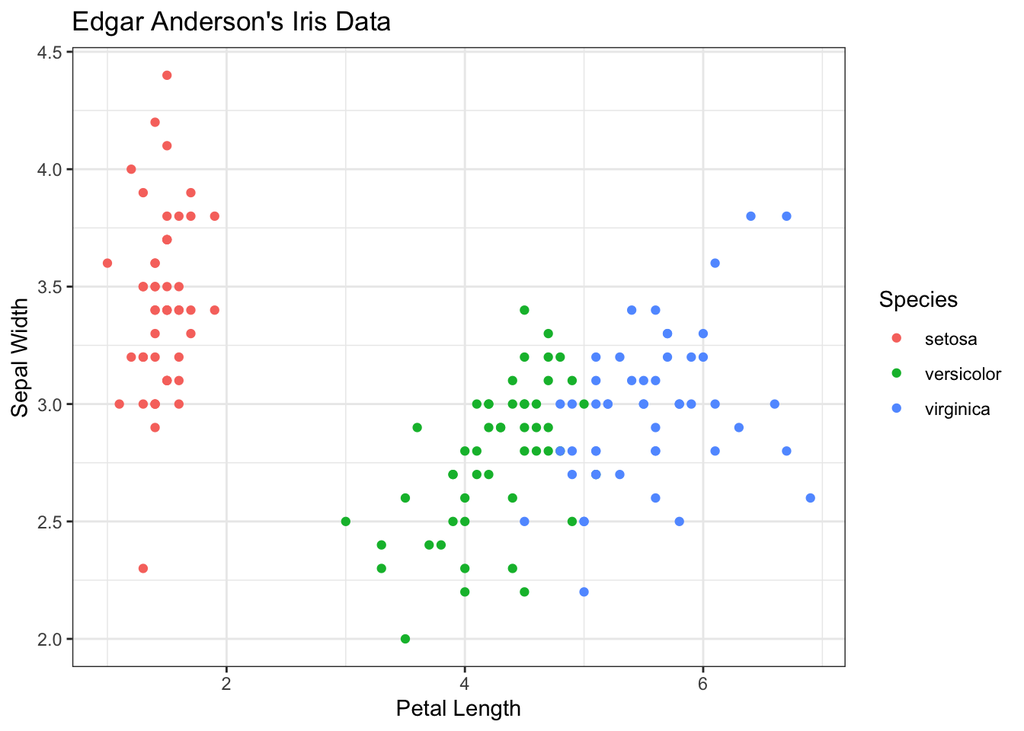

```r
ggplot(iris, aes(x = Petal.Length, y = Sepal.Width, color = Species)) + geom_point() + labs(title = "Edgar Anderson's Iris Data", x = "Petal Length", y = "Sepal Width") + theme_bw()
```

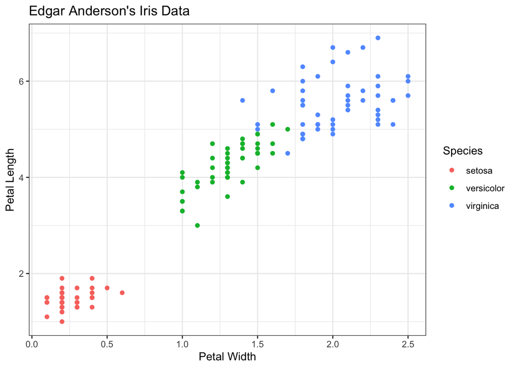

```r
ggplot(iris, aes(x = Petal.Width, y = Petal.Length, color = Species)) + geom_point() + labs(title = "Edgar Anderson's Iris Data", x = "Petal Width", y = "Petal Length") + theme_bw()
```

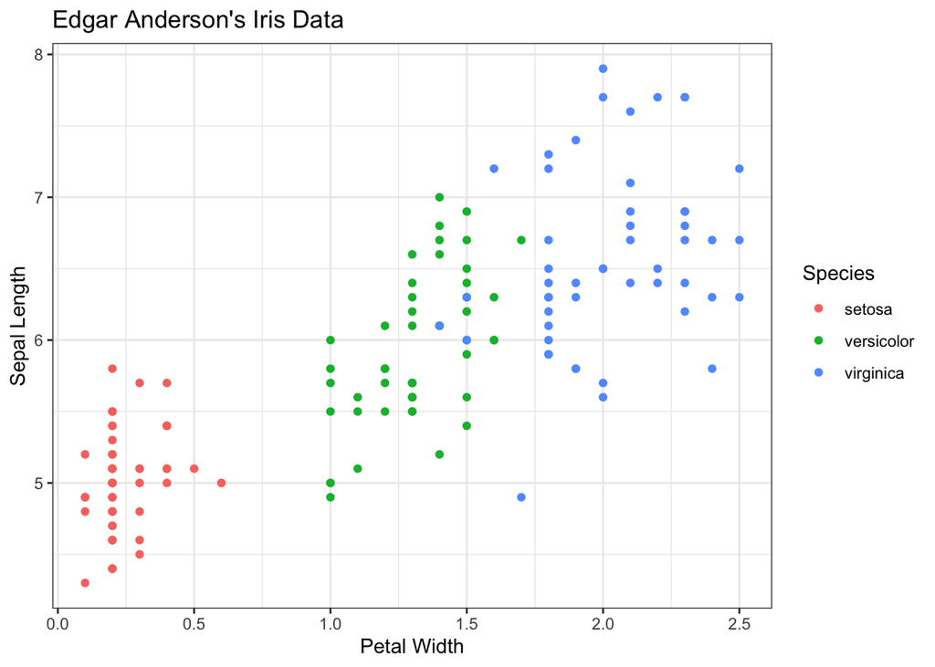

```r
ggplot(iris, aes(x = Petal.Width, y = Sepal.Length, color = Species)) + geom_point() + labs(title = "Edgar Anderson's Iris Data", x = "Petal Width", y = "Sepal Length") + theme_bw()
```

[figure not shown]

```r
ggplot(iris, aes(x = Petal.Width, y = Sepal.Width, color = Species)) + geom_point() + labs(title = "Edgar Anderson's Iris Data", x = "Petal Length", y = "Sepal Width") + theme_bw()
```

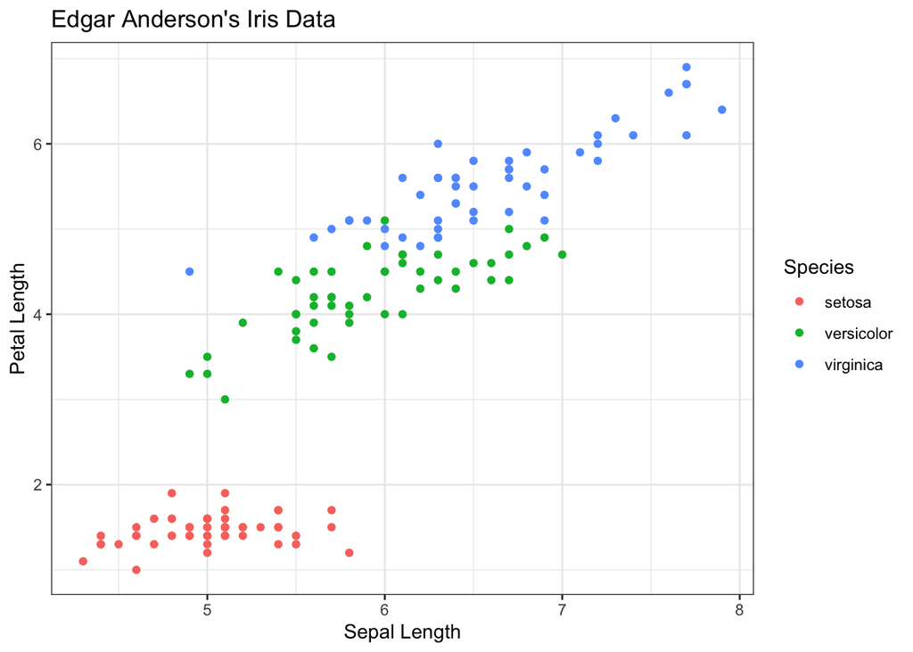

```r
ggplot(iris, aes(x = Sepal.Length, y = Petal.Length, color = Species)) + geom_point() + labs(title = "Edgar Anderson's Iris Data", x = "Sepal Length", y = "Petal Length") + theme_bw()
```

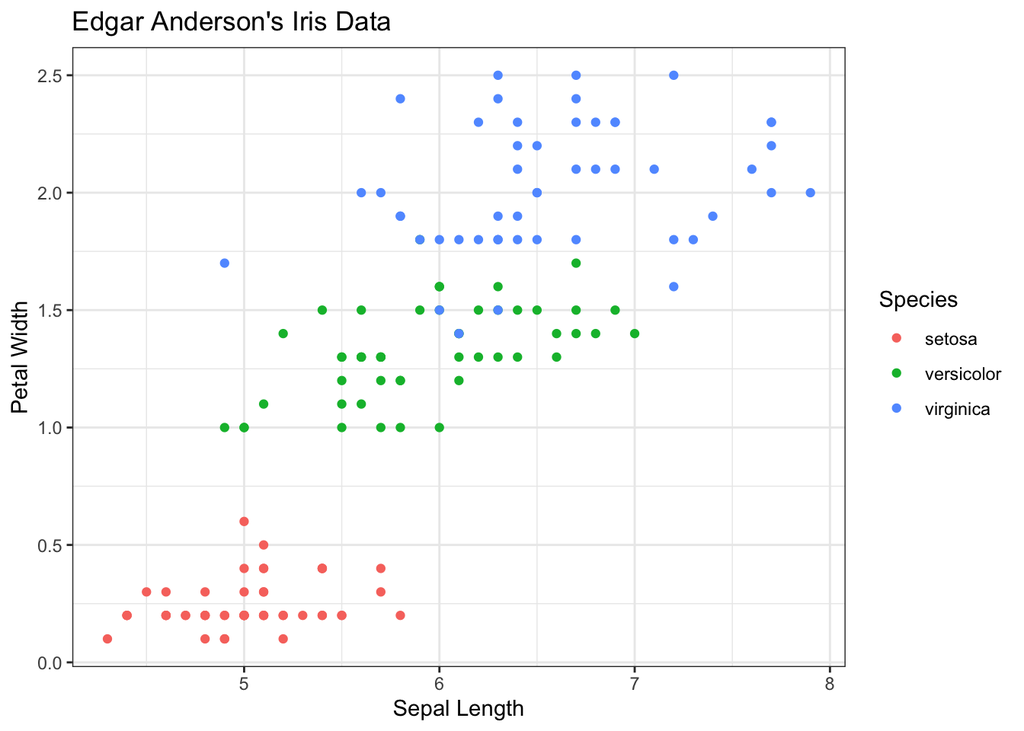

```r
ggplot(iris, aes(x = Sepal.Length, y = Petal.Width, color = Species)) + geom_point() + labs(title = "Edgar Anderson's Iris Data", x = "Sepal Length", y = "Petal Width") + theme_bw()
```

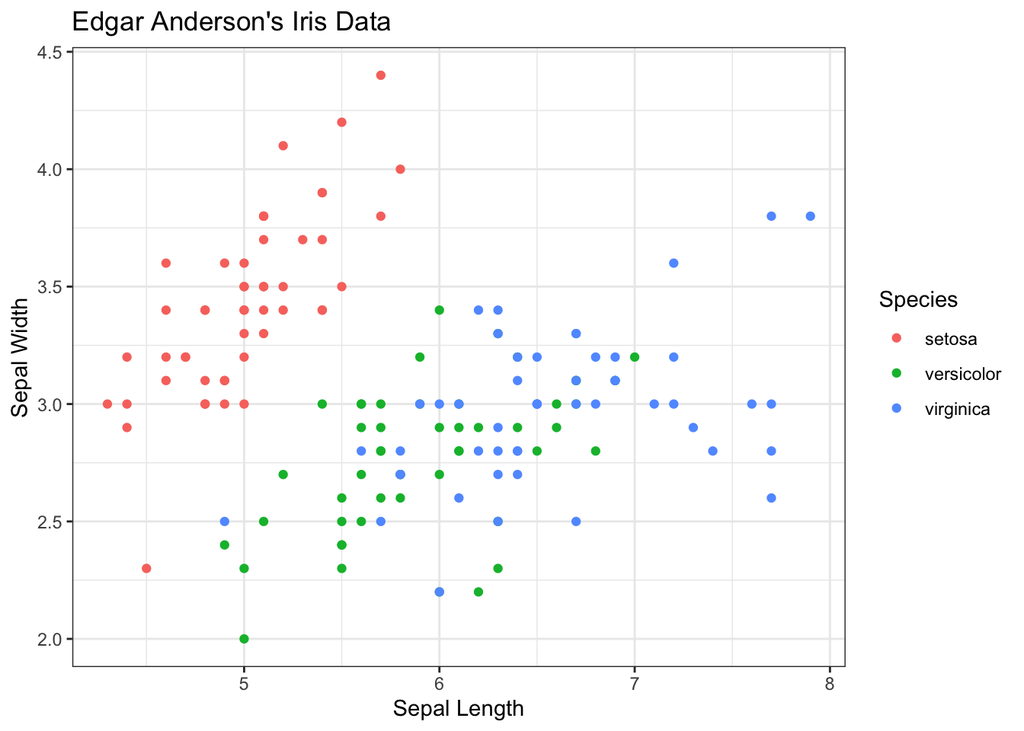

```r
ggplot(iris, aes(x = Sepal.Length, y = Sepal.Width, color = Species)) + geom_point() + labs(title = "Edgar Anderson's Iris Data", x = "Sepal Length", y = "Sepal Width") + theme_bw()
```

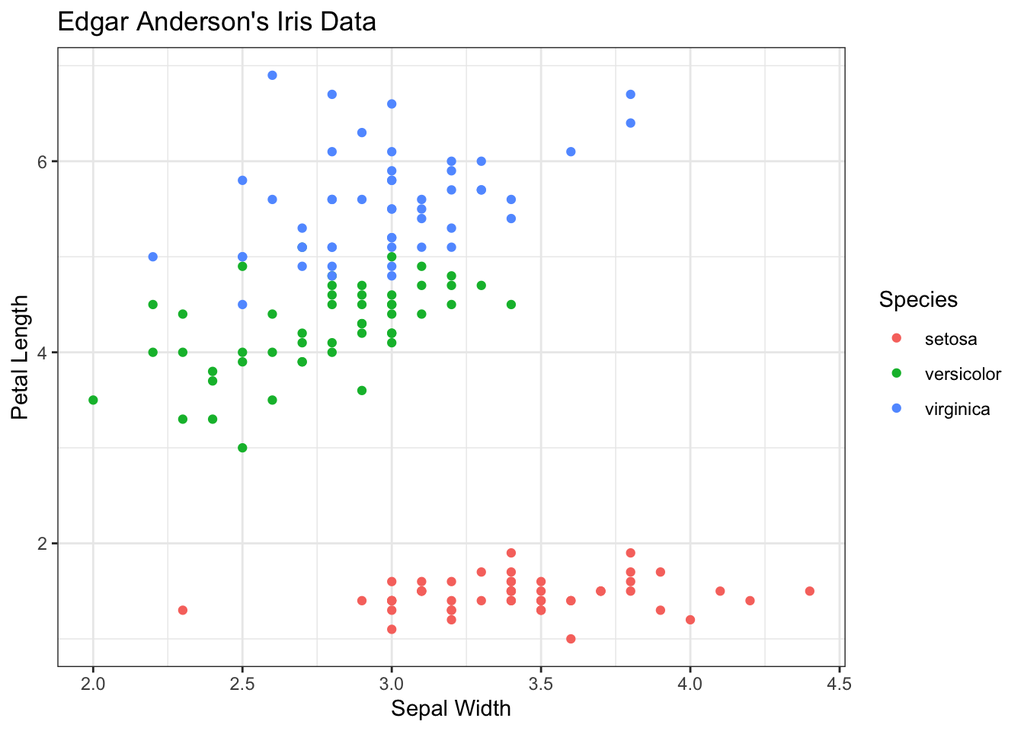

```r
ggplot(iris, aes(x = Sepal.Width, y = Petal.Length, color = Species)) + geom_point() + labs(title = "Edgar Anderson's Iris Data", x = "Sepal Width", y = "Petal Length") + theme_bw()
```

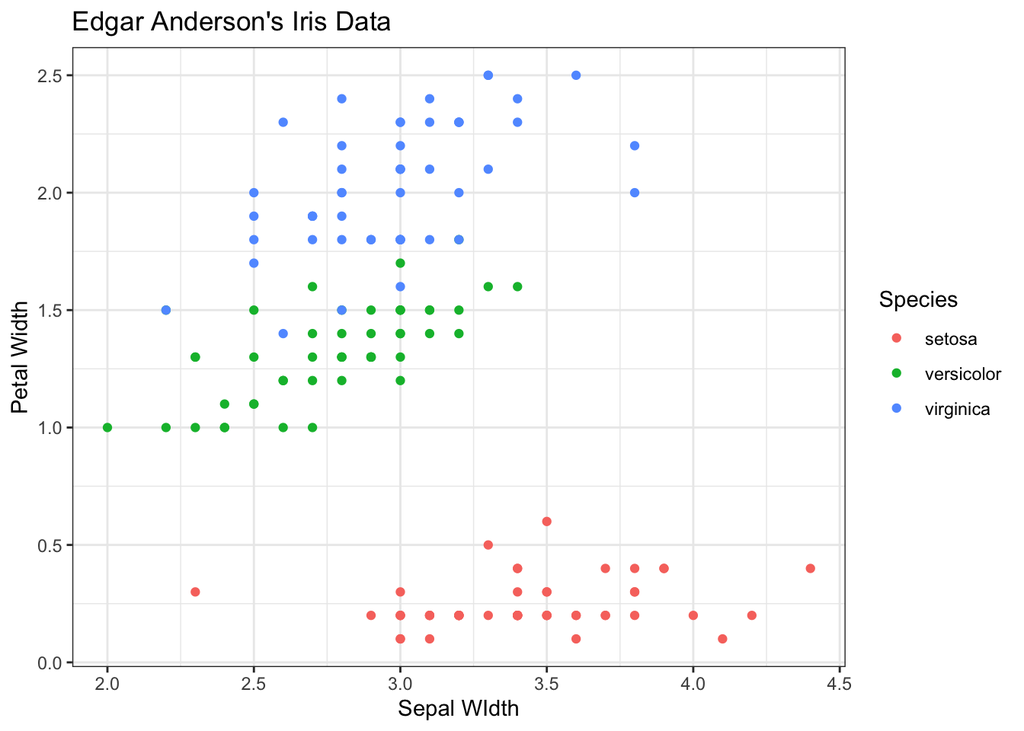

```r
ggplot(iris, aes(x = Sepal.Width, y = Petal.Width, color = Species)) + geom_point() + labs(title = "Edgar Anderson's Iris Data", x = "Sepal WIdth", y = "Petal Width") + theme_bw()
```

[figure not shown]

```r
ggplot(iris, aes(x = Sepal.Width, y = Sepal.Length, color = Species)) + geom_point() + labs(title = "Edgar Anderson's Iris Data", x = "Petal Length", y = "Sepal Length") + theme_bw()
```

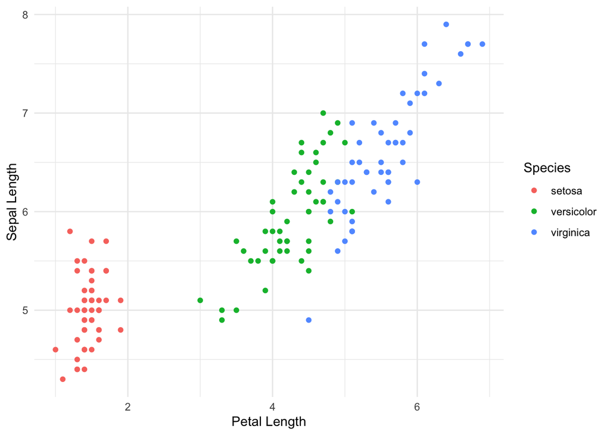

```r
ggplot(iris, aes(x = Petal.Length, y = Sepal.Length, color = Species)) + geom_point() + labs(x = "Petal Length", y = "Sepal Length") + theme_minimal()
```

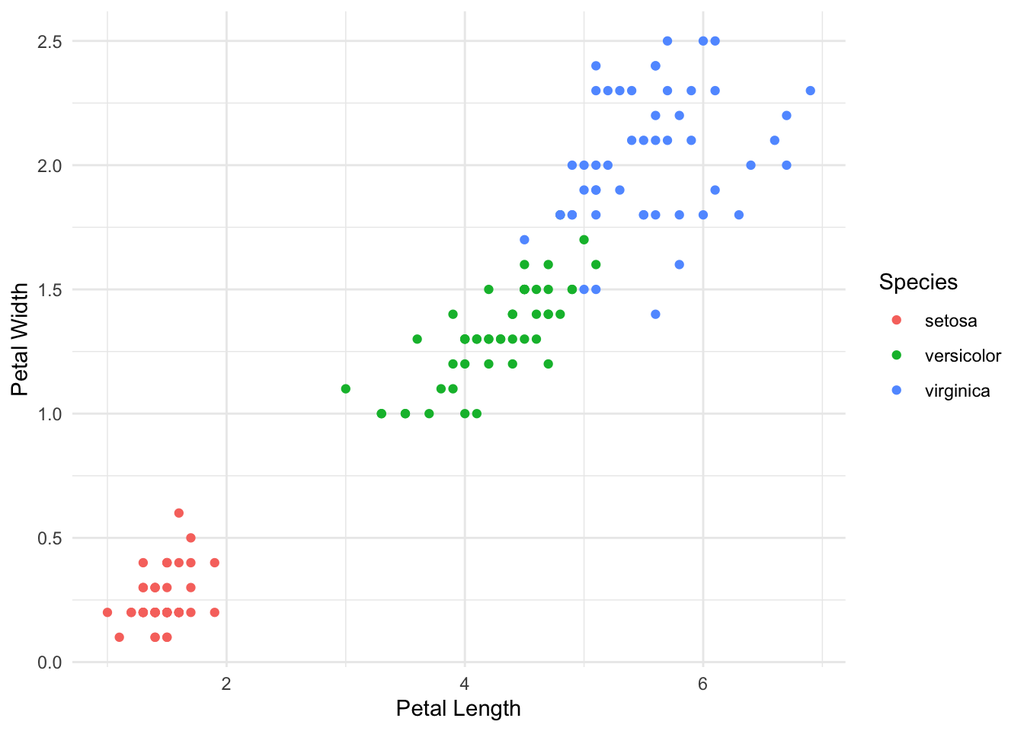

```r
ggplot(iris, aes(x = Petal.Length, y = Petal.Width, color = Species)) + geom_point() + labs(x = "Petal Length", y = "Petal Width") + theme_minimal()
```

## Question 4: what data did you use to evalate which two measurements gave the best prediction of species? Based on this data, are you confident in Edgar Anderson’s predictions? Why or why not? A: The petal length and width were the two measurements the gave the best predictions of species. Based on this data, I am confident in Anderson’s predictions because of the sample size/quality and the big sepaation between species in the petal measurements.

# Part II: Geographical and temporal data

```r
library(dismo)
```

```r
get.gbif <- function(genus, species, na.rm = TRUE, crop = TRUE) {
    # GBIF query
    gps <- gbif(genus, species, geo = FALSE)
    # drop NA entries; note that this option is visited only with na.rm=TRUE
    if (na.rm) {
        gps <- subset(gps, !is.na(lon) & !is.na(lat))
    }
    if (crop) {
        keep <- c(which(colnames(gps) == "species"), which(colnames(gps) == "lat"), which(colnames(gps) == "lon"), which(colnames(gps) ==
            "month"))
        gps <- gps[keep]
    }
    return(gps)
}

setosa <- get.gbif("Iris", "setosa")
versicolor <- get.gbif("Iris", "versicolor")
virginica <- get.gbif("Iris", "virginica")

iris_gps <- bind_rows(setosa, versicolor, virginica)


write_csv(iris_gps, file = "iris_gps.csv", col_names = TRUE)
iris_gps <- read_csv("iris_gps.csv")
library(maps)
world.map <- map_data(map = "world")
us.map <- map_data(map = "usa")
ggplot2::theme_set(theme_bw())
```

## Question 1: observation? A: a lot of the observations are in africa, and when looking at it closer, it seems that it tends to be southern tip or mid-eastern shore.

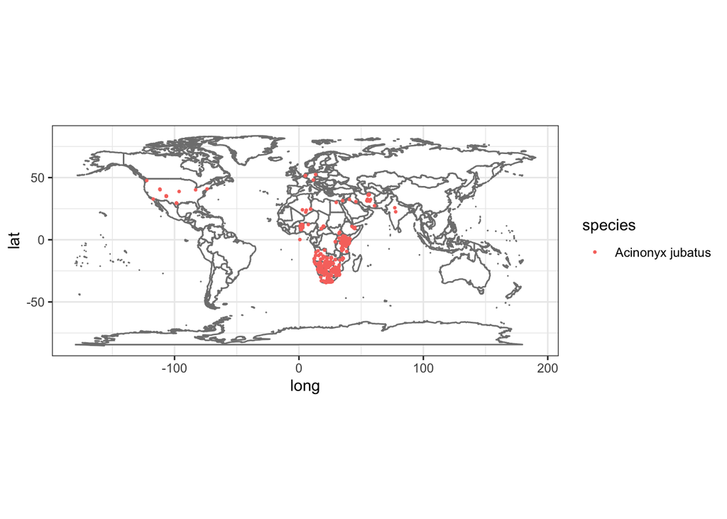

```r
species_name <- "Acinonyx jubatus"
cheetah_data <- gbif(genus = "Acinonyx", species = "jubatus", geo = TRUE)
ggplot(world.map, aes(long, lat, group = group)) + geom_polygon(fill = "white", colour = "grey50") + coord_quickmap() + geom_point(data = cheetah_data,
    mapping = aes(x = lon, y = lat, group = species, color = species), size = 0.5)
```

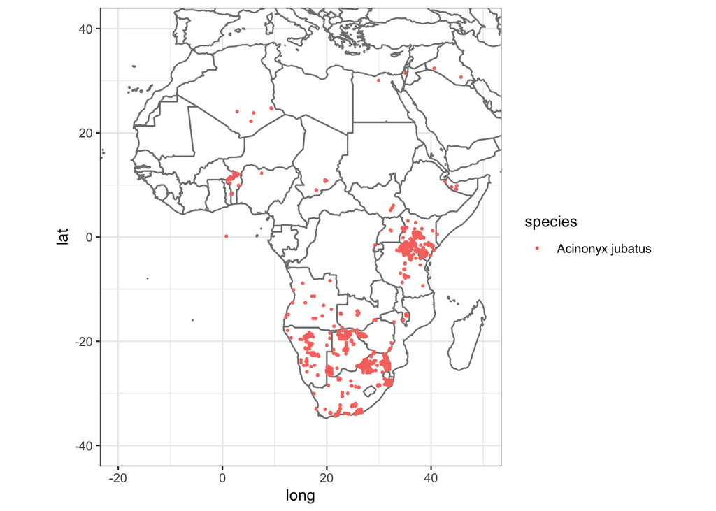

```r
ggplot(world.map, aes(long, lat, group = group)) + geom_polygon(fill = "white", colour = "grey50") + coord_quickmap(xlim = c(-20,50), ylim = c(-40,40)) + geom_point(data = cheetah_data,
    mapping = aes(x = lon, y = lat, group = species, color = species), size = 0.5)
```

## Question 2

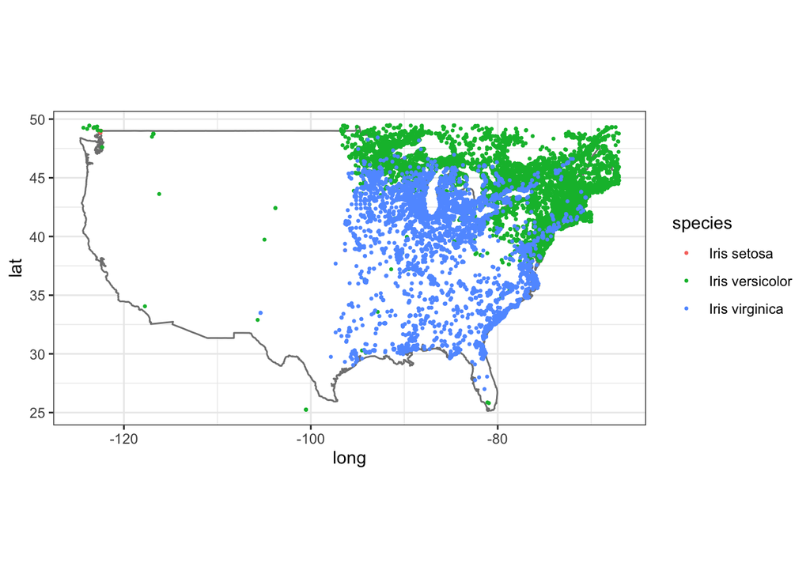

```r
iris_us <- subset(iris_gps, lon >= -124.6814 & lon <= -67.00742 & lat >= 25.12993 & lat <= 49.48323)
ggplot(us.map, aes(long, lat, group = group)) + geom_polygon(fill = "white", colour = "grey50") + coord_quickmap() + geom_point(data = iris_us,
    mapping = aes(x = lon, y = lat, group = species, color = species), size = 0.5)
```

## Question 3:

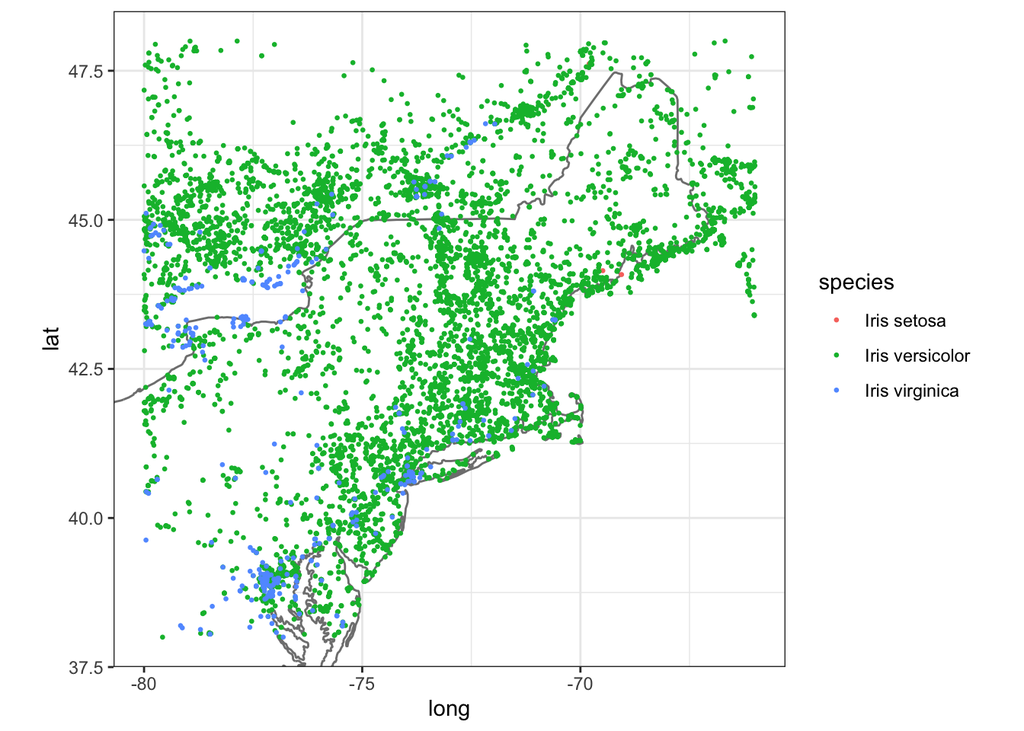

```r
iris_ne <- subset(iris_gps, lon >= -80 & lon <= -66 & lat >= 38 & lat <= 48)
ggplot(us.map, aes(long, lat, group = group)) + geom_polygon(fill = "white", color = "grey50") + coord_quickmap(xlim = c(-80,-66), ylim = c(38,48)) + geom_point(data = iris_ne, aes(x = lon, y = lat, group = species, color = species), size = 0.5)
```

## Question 4 What do you observe about the distribution of our three potential species in the US? the versicolor species is the most prevalent, and tends to be near the border of the country, while the virginica is widespread in the same area as well, and there is minimal amounts of the setosa. What did this exercise tell you about our three potential species of iris? Describe the distribution of each of the three potential species. This tell me that there isn’t complete separation between species, seen from the strong overlap of the virginica and versicolor. Produce an argument about what our species occurrence data means in terms of their current species delineations. There must be a prezygotic reproductive barrier for the species to exist in the same general area, such as temporal or behavioral. ## Question 5: write a paragraph on potential problems with evaluating reproductive isolation using this method. Temporal isolation can be a major factor as to what lead to the speciation of these threee iris species. However, because the data is covered in month blocks, the weeks within the months are all grouped into one month, and this can hide the potential timing differences in flowering week-to-week. Additionally, only using a histogram to evaluate this method of reproductive isolation can be problematic because of how incomplete of a data graph and data analysis method this is.

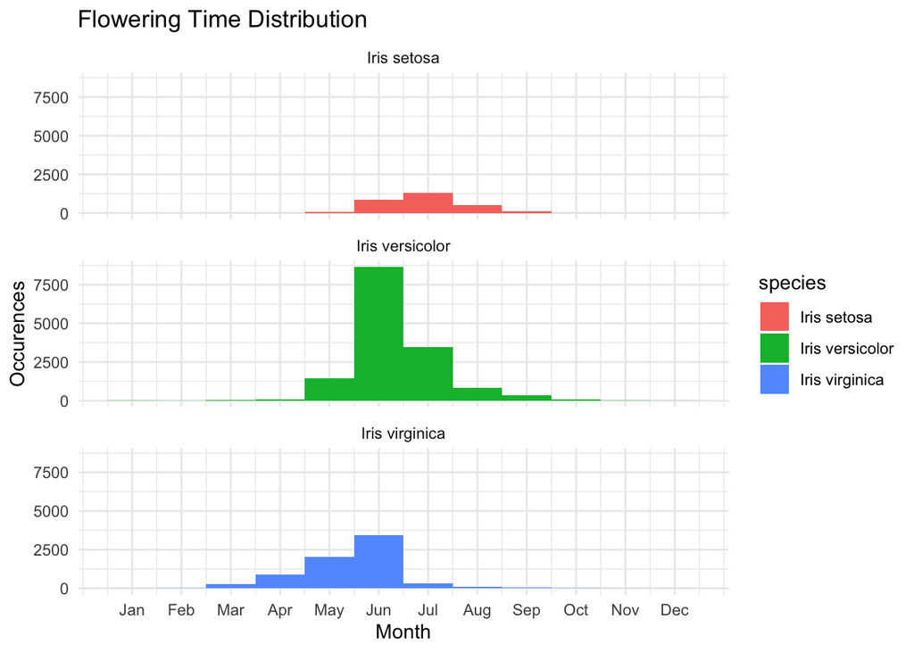

```r
ggplot(data = iris_gps, aes(x = month, group = species, fill = species)) + geom_histogram(position = "dodge",
    binwidth = 1) + facet_wrap(~species, nrow = 3) + scale_x_continuous(breaks = 1:12, labels = c("Jan", "Feb", "Mar", "Apr", "May", "Jun", "Jul", "Aug", "Sep", "Oct", "Nov", "Dec")) + labs(title = "Flowering Time Distribution", x = "Month", y = "Occurences") + theme_minimal()
```

# Part III: Chromosomal data

```r
iris_chrom_dataset <- read.csv("iris_chromosomes.csv", skip = 1)

head(iris_chrom_dataset)
```

```
##                                  id                      source internal_id
## 1                 ipcn-api-dl-53132                 ipcn-api-dl    16600207
## 2 book-atlas-flowering-plants-11026 book-atlas-flowering-plants          NA
## 3                 ipcn-api-dl-53159                 ipcn-api-dl    16600226
## 4                 ipcn-api-dl-53194                 ipcn-api-dl    16600242
## 5                 ipcn-api-dl-53195                 ipcn-api-dl    16600242
## 6                 ipcn-api-dl-53838                 ipcn-api-dl    16602561
##   major_group    family genus
## 1 Angiosperms Iridaceae  Iris
## 2 Angiosperms Iridaceae  Iris
## 3 Angiosperms Iridaceae  Iris
## 4 Angiosperms Iridaceae  Iris
## 5 Angiosperms Iridaceae  Iris
## 6 Angiosperms Iridaceae  Iris
##                                                 original_name
```

[output cut: 41 more lines]

```r
iris_chrom <- iris_chrom_dataset %>%
    dplyr::select(resolved_name, sporophytic, parsed_n) %>%
    separate(resolved_name, into = c("genus", "species"), sep = " ", remove = TRUE, extra = "drop")

head(iris_chrom)
```

```
##   genus   species sporophytic parsed_n
## 1  Iris acutiloba          20       10
## 2  Iris acutiloba          20       10
## 3  Iris acutiloba          20       10
## 4  Iris acutiloba          20       10
## 5  Iris acutiloba          20       10
## 6  Iris acutiloba          20       10
```

```r
setosa_chrom <- iris_chrom %>%
    filter(species == "setosa")

setosa_chrom
```

```
##    genus species sporophytic   parsed_n
## 1   Iris  setosa          38         19
## 2   Iris  setosa          38         19
## 3   Iris  setosa          38         19
## 4   Iris  setosa          38         19
## 5   Iris  setosa          38         19
## 6   Iris  setosa          38         19
## 7   Iris  setosa          36         18
## 8   Iris  setosa          38         19
## 9   Iris  setosa          38         19
## 10  Iris  setosa          38         19
## 11  Iris  setosa          38         19
## 12  Iris  setosa    34,36,38 17, 18, 19
## 13  Iris  setosa          38         19
## 14  Iris  setosa     "34-36"      17,18
## 15  Iris  setosa          38         19
## 16  Iris  setosa       c. 54         27
## 17  Iris  setosa       c. 54         27
```

```r
virginica_chrom <- iris_chrom %>%
    filter(species == "virginica")

virginica_chrom
```

```
##   genus   species sporophytic   parsed_n
## 1  Iris virginica       70,72     35, 36
## 2  Iris virginica  54, 56, 70 27, 28, 35
```

```r
versicolor_chrom <- iris_chrom %>%
    filter(species == "versicolor")

versicolor_chrom
```

```
##   genus    species sporophytic parsed_n
## 1  Iris versicolor         108       54
## 2  Iris versicolor         108       54
## 3  Iris versicolor         108       54
## 4  Iris versicolor         108       54
## 5  Iris versicolor 72, 84, 105   36, 42
```

## Question 1

```r
mode <- function(x) {
  x <- x[!is.na(x)]
  ux <- unique(x)
  ux[which.max(tabulate(match(x, ux)))]
}
iris_chrom$sporophytic <- as.numeric(iris_chrom$sporophytic)
iris_mode <- iris_chrom %>%
  group_by(species) %>%
  summarize(sporophytic_mode = mode(sporophytic))
head(iris_mode, 20)
```

```
## # A tibble: 20 × 2
##    species        sporophytic_mode
##    <chr>                     <dbl>
##  1 acutiloba                    20
##  2 afghanica                    22
##  3 aitchisonii                  34
##  4 alberti                      24
##  5 albicans                     44
##  6 albomarginata                50
##  7 anguifuga                    34
##  8 antilibanotica               20
##  9 aphylla                      48
## 10 arenaria                     22
## 11 assadiana                    20
## 12 atrofusca                    20
## 13 atropatana                   18
## 14 atropurpurea                 20
## 15 aucheri                      24
## 16 auranitica                   20
## 17 barnumiae                    20
## 18 basaltica                    20
## 19 bicapitata                   40
## 20 biglumis                     40
```

## Question 2

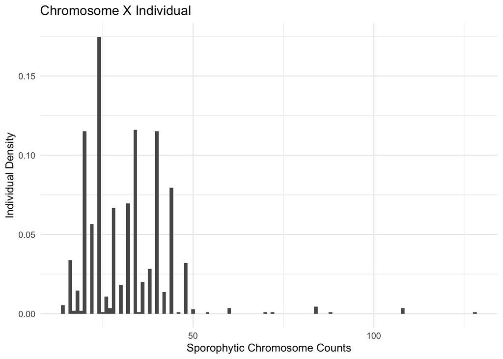

```r
ggplot(data = iris_chrom, aes(x = sporophytic, y = after_stat(density))) + geom_histogram(binwidth = 1) + labs(title = "Chromosome X Individual", x = "Sporophytic Chromosome Counts", y = "Individual Density") + theme_minimal()
```

## Question 3: What is the “mode” sporophytic chromosome value for each species? What do you notice about the relationship between these values? setosa (38), versicolor (108), virginica (NA). This shows that versicolor likely experiences polyploidy, which speciated it instantly, likely from the setosa. However, the lack of data from virginica could introduce multiple unknowns.

# Part IV: Producing a scientific argument

## Question 1:

Using (1) morphological, (2) geographic, (3) temporal, and (4) chromosomal data, explain the best-supported relationship between these three potential species. The best supported relationship would eb that the versicolor and virginica would be more closely related than the setosa, due to the geological and temporal similarities.

In your estimation, were the original species designations by Anderson correct? Did the additional geographic, temporal, and chromosomal data add or detract from this initial hypothesis? Why or why not I believe he did correctly identify the species based on the morphology, and while the additional data could add uncertainties, it seems that they mostly support the species.